# consensus_score

**sklearn.metrics.consensus_score(*a*, *b*, *, *similarity='jaccard'*)[[source]](https://github.com/scikit-learn/scikit-learn/blob/cc50648cc/sklearn/metrics/cluster/_bicluster.py#L52)**

The similarity of two sets of biclusters.

Similarity between individual biclusters is computed. Then the best matching between sets is found by solving a linear sum assignment problem, using a modified Jonker-Volgenant algorithm. The final score is the sum of similarities divided by the size of the larger set.

Read more in the User Guide.

**Parameters:**

**a**tuple (rows, columns)**

Tuple of row and column indicators for a set of biclusters.

**b**tuple (rows, columns)**

Another set of biclusters like `a`.

**similarity**‘jaccard’ or callable, default=’jaccard’**

May be the string “jaccard” to use the Jaccard coefficient, or any function that takes four arguments, each of which is a 1d indicator vector: (a_rows, a_columns, b_rows, b_columns).

**Returns:**

**consensus_score**float**

Consensus score, a non-negative value, sum of similarities divided by size of larger set.

See also

**[`scipy.optimize.linear_sum_assignment`](https://docs.scipy.org/doc/scipy/reference/generated/scipy.optimize.linear_sum_assignment.html#scipy.optimize.linear_sum_assignment)**

Solve the linear sum assignment problem.

#### References

- Hochreiter, Bodenhofer, et. al., 2010. [FABIA: factor analysis for bicluster acquisition](https://www.ncbi.nlm.nih.gov/pmc/articles/PMC2881408/).

#### Examples

```
>>> from sklearn.metrics import consensus_score
>>> a = ([[True, False], [False, True]], [[False, True], [True, False]])
>>> b = ([[False, True], [True, False]], [[True, False], [False, True]])
>>> consensus_score(a, b, similarity='jaccard')
1.0
```

## Gallery examples

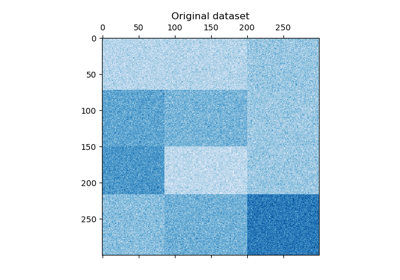

A demo of the Spectral Biclustering algorithm

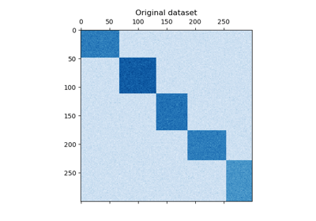

A demo of the Spectral Co-Clustering algorithm

© 2007–2026 The scikit-learn developers  
Licensed under the 3-clause BSD License.  
https://scikit-learn.org/1.9/modules/generated/sklearn.metrics.consensus_score.html